# Lab 11: Simulation and Power Analysis

Johanna Ravenhurst

2022-12-09

I didn’t work with other students.

```r
#Setup
rm(list = ls())
require(here)
require(rgl)
birds   = read.csv(here("data", "bird.sub.csv"))
hab     = read.csv(here("data", "hab.sub.csv"))
birdhab = merge(
  birds,
  hab, by=c("basin", "sub"))

head(birdhab)
```

```
##   basin sub tsta AMCR AMDI       AMGO      AMRO    BAEA       BASW       BCCH
## 1     D  AL   35    0    0 0.28571429 0.5428571 0.00000 0.00000000 0.00000000
## 2     D  BC   32    0    0 0.09375000 0.3125000 0.00000 0.00000000 0.00000000
## 3     D  CH   37    0    0 0.05405405 0.5945946 0.00000 0.05405405 0.05405405
## 4     D  DC   34    0    0 0.02941176 0.5588235 0.00000 0.00000000 0.00000000
## 5     D  HC   35    0    0 0.31428571 0.5142857 0.00000 0.00000000 0.08571429
## 6     D  LF   32    0    0 0.53125000 0.4687500 0.03125 0.00000000 0.15625000
##         BEKI       BEWR       BGWA       BHCO      BHGR       BRCR      BTPI
## 1 0.00000000 0.05714286 0.02857143 0.02857143 0.4285714 0.02857143 0.4857143
## 2 0.00000000 0.03125000 0.03125000 0.00000000 0.4062500 0.43750000 0.2500000
## 3 0.05405405 0.02702703 0.08108108 0.00000000 0.7567568 0.37837838 0.8378378
## 4 0.00000000 0.00000000 0.05882353 0.00000000 0.6176471 0.55882353 0.6470588
## 5 0.02857143 0.28571429 0.00000000 0.02857143 0.7142857 0.34285714 0.4000000
## 6 0.00000000 0.25000000 0.12500000 0.03125000 0.8437500 0.28125000 0.5937500
##   BUGR       BUSH       CAGO      CBCH      CEWA COHA      COME       CONI
```

[output cut: 111 more lines]

# Walkthrough code not included in output

#Scatterplot

#Simple linear regression

This model suggests a significant relationship between late-successional forest and Brown Creeper abundance, but this could be a product of chance. There is an issue with using linear regression due to the potential heterogeneous variance in these data.

#Deterministic Model: Linear Function

#Stochastic Model: Normal Distribution

#Simulation Function

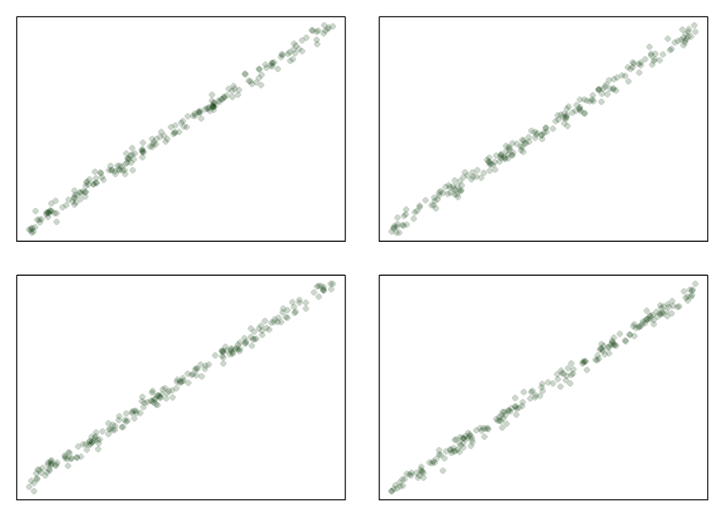

```r
linear_simulator = function(x, y_int, slope, st_dev)
{
  y_det = y_int + slope * x
  output_sim = rnorm(n = length(x), mean = y_det, sd = st_dev)
  return (output_sim)
}



#test
n = 200

par(mfrow = c(2, 2), mar = c(1, 1, 1, 1))
for (i in 1:4)
{
  x = runif(n = n)
  plot(
    x,
    linear_simulator(x, y_int = 1, slope = 4.5, st_dev = 0.1),
    main = "", xlab = "x", ylab = "y",
    pch = 16, col = rgb(0, 0.2, 0, 0.2),
    axes = FALSE)
  box()
}
```

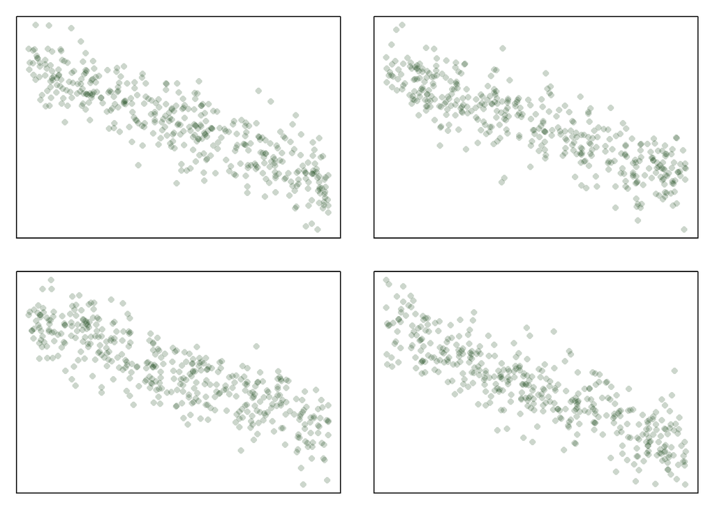

```r
#test2
n = 400

par(mfrow = c(2, 2), mar = c(1, 1, 1, 1))
for (i in 1:4)
{
  x = runif(n = n)
  plot(
    x, linear_simulator(x, y_int = 10, slope = -6.5, st_dev = 1.1),
    main = "", xlab = "x", ylab = "y",
    pch = 16, col = rgb(0, 0.2, 0, 0.2),
    axes = FALSE)
  box()
}
```

#Build the simulation

```r
#Retrieve the model coefficients
fit_1_coefs = coefficients(fit_1)
str(fit_1_coefs)
```

```
##  Named num [1:2] 0.0991 0.00584
##  - attr(*, "names")= chr [1:2] "(Intercept)" "ls"
```

```r
#Retrieve the standard deviation parameter

fit_1_summary = summary(fit_1)
str(fit_1_summary)
```

```
## List of 11
##  $ call         : language lm(formula = BRCR ~ ls, data = birdhab)
##  $ terms        :Classes 'terms', 'formula'  language BRCR ~ ls
##   .. ..- attr(*, "variables")= language list(BRCR, ls)
##   .. ..- attr(*, "factors")= int [1:2, 1] 0 1
##   .. .. ..- attr(*, "dimnames")=List of 2
##   .. .. .. ..$ : chr [1:2] "BRCR" "ls"
##   .. .. .. ..$ : chr "ls"
##   .. ..- attr(*, "term.labels")= chr "ls"
##   .. ..- attr(*, "order")= int 1
##   .. ..- attr(*, "intercept")= int 1
##   .. ..- attr(*, "response")= int 1
##   .. ..- attr(*, ".Environment")=<environment: R_GlobalEnv>
##   .. ..- attr(*, "predvars")= language list(BRCR, ls)
##   .. ..- attr(*, "dataClasses")= Named chr [1:2] "numeric" "numeric"
##   .. .. ..- attr(*, "names")= chr [1:2] "BRCR" "ls"
##  $ residuals    : Named num [1:30] -0.0747 -0.1297 0.0256 0.1255 0.1009 ...
##   ..- attr(*, "names")= chr [1:30] "1" "2" "3" "4" ...
##  $ coefficients : num [1:2, 1:4] 0.099104 0.00584 0.050764 0.000871 1.952266 ...
##   ..- attr(*, "dimnames")=List of 2
##   .. ..$ : chr [1:2] "(Intercept)" "ls"
##   .. ..$ : chr [1:4] "Estimate" "Std. Error" "t value" "Pr(>|t|)"
##  $ aliased      : Named logi [1:2] FALSE FALSE
##   ..- attr(*, "names")= chr [1:2] "(Intercept)" "ls"
##  $ sigma        : num 0.141
##  $ df           : int [1:3] 2 28 2
##  $ r.squared    : num 0.616
##  $ adj.r.squared: num 0.602
##  $ fstatistic   : Named num [1:3] 45 1 28
##   ..- attr(*, "names")= chr [1:3] "value" "numdf" "dendf"
##  $ cov.unscaled : num [1:2, 1:2] 0.129129 -0.001909 -0.001909 0.000038
##   ..- attr(*, "dimnames")=List of 2
##   .. ..$ : chr [1:2] "(Intercept)" "ls"
##   .. ..$ : chr [1:2] "(Intercept)" "ls"
##  - attr(*, "class")= chr "summary.lm"
```

```r
fit_1_summary$sigma
```

```
## [1] 0.1412668
```

```r
#Store the intercept, slope, and standard deviation parameters from the model into the following variables:
int_obs <- fit_1_coefs["(Intercept)"]
slope_obs <- fit_1_coefs["ls"]
sd_obs <- fit_1_summary$sigma
```

#Simulate data

NOTE: I kept getting errors here because x and y are different lengths “Error in xy.coords(x, y) : ‘x’ and ‘y’ lengths differ”. Finally I was able to get the linear simulator function to work properly after reviewing some material on Google and thinking about it some more.

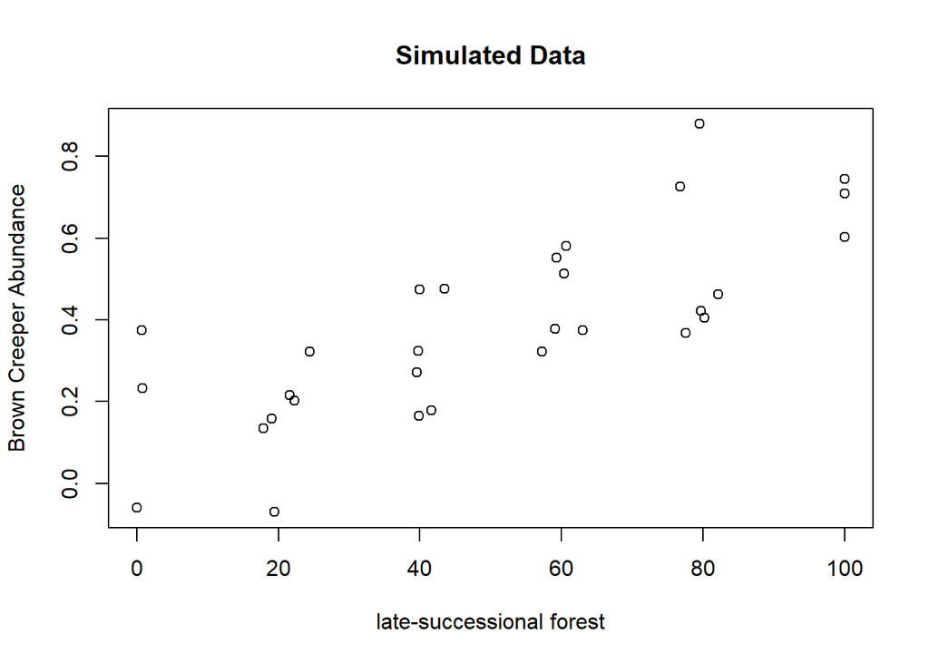

```r
plot(
  x = birdhab$ls,
  y = linear_simulator(
    x = birdhab$ls,
    y_int = int_obs,
    slope = slope_obs,
    st_dev = sd_obs
  ),
  main = "Simulated Data",
  xlab = "late-successional forest",
  ylab = "Brown Creeper Abundance")
```

```r
#same length now!!
length(birdhab$ls)
```

```
## [1] 30
```

```r
length(linear_simulator(
    birdhab$ls,
    int_obs,
    slope_obs,
    sd_obs
  ))
```

```
## [1] 30
```

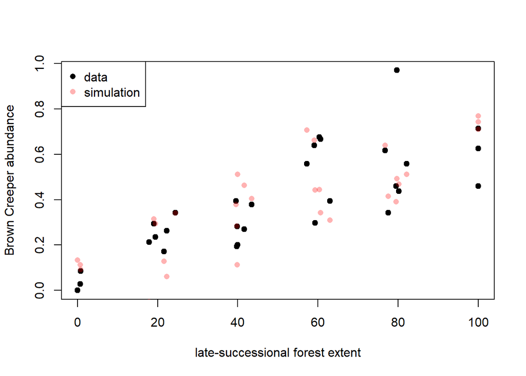

```r
#alternative test
plot(
  birdhab$ls, birdhab$BRCR,
  xlab = "late-successional forest extent",
  ylab = "Brown Creeper abundance",
  pch = 19)

points(
  x = birdhab$ls,
  y = linear_simulator(
    x = birdhab$ls,
    y_int = int_obs,
    slope = slope_obs,
    st_dev = sd_obs
  ),
  col = adjustcolor("red", alpha = 0.3),
  pch = 16)

legend(
  "topleft",
  legend = c("data", "simulation"),
  pch = 16,
  col = c(1, adjustcolor("red", alpha = 0.3)))
```

I ran the model a few more times to see how variable the results are.

Is the new pattern of points the same as the original pattern? Are there any notable discrepancies? - the pattern looks similar, but sometimes there is more of a linear pattern without the concerning megaphone shape that I noted in the original data.

Does the pattern of the simulated points vary much among realizations? - it’s roughly similar, the pattern looks linear with more/less variance.

After running the model a few times, do you notice any potential problems with the model? - no, I think this looks fine

Walkthrough says there are sometimes negative values, so I will need to alter the function to make sure it doesn’t return negative values for brown creeper abundance (y). Hint is to use a logical test.

#Single simulation - find out if we can reject the null with a single experiment

#Repeated Simulations to estimate the power

Based on the simulation output:

```
How many simulations found a significant slope coefficient? - all 1000 simulations
What is our statistical power? - 1
```

```r
#function for simulation loops
linear_sim_fit = function(x, slope, y_int, st_dev)
{
  y_sim = linear_simulator(
    x = x,
    y_int = y_int,
    slope = slope,
    st_dev = st_dev
  )
  fit_sim = lm(y_sim ~ x)
  return(fit_sim)
}
```

# Simulating Effect Sizes

#Simulating Sample Sizes

#How much power is lost if we reduce the sample size from 30 to 20? - none

#Effect Size and Sample Size - vary 2 parameters instead of just 1

#Plotting a matrix using image()

#Contour plotting

#Static perpective plot

# **Q1-2: Dispersion and Statistical Power**

observed standard deviation was 0.14 - so try range of pop sd 0.01 - 0.42

```r
alpha = 0.05
n_sims = 100
p_vals = numeric(n_sims)

# What was the observed standard deviation?
sd_obs
```

```
## [1] 0.1412668
```

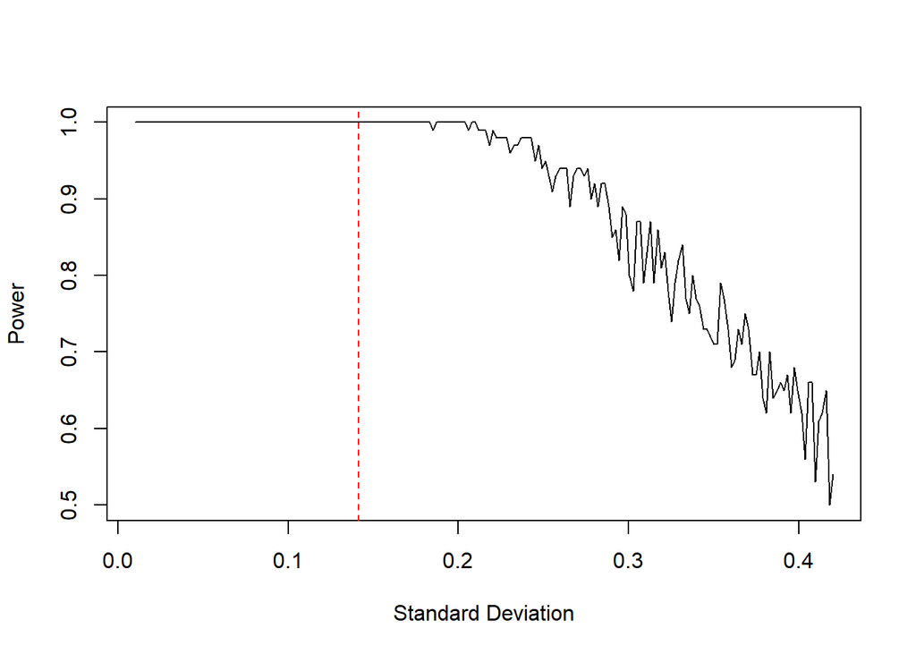

```r
# specify the number of different standard deviation values to simulate:
n_sds = 200
pop_sds = seq(0.01, 0.42, length.out = n_sds)

pop_sd_powers = numeric(n_sds)

for(j in 1:length(pop_sds))
{
  pop_sds_j = pop_sds[j]
  for(i in 1:n_sims)
  {
    fit_sim = linear_sim_fit(
      x = birdhab$ls,
      y_int = int_obs,
      slope = slope_obs,
      st_dev = pop_sds_j
      )
    p_vals[i] = summary(fit_sim)$coefficients[2, 'Pr(>|t|)']
  }
  pop_sd_powers[j] = sum(p_vals < alpha) / n_sims
}

sim_output_dispersion = data.frame(
  sd = pop_sds,
  power = pop_sd_powers )

# You should save your simulation results so you don't have to run it every time.
save(
  sim_output_dispersion,
  file = here::here("data", "lab_ll_dat_dispersion_sim.RData"))


#Q1 (2 pts.): Include a figure of your line plot in your report.
# Line plot of standard deviation (x-axis) and statistical power (y-axis)
plot(
  power ~ sd, data = sim_output_dispersion,
  type = 'l', xlab = 'Standard Deviation', ylab = 'Power')


# Add a dotted vertical red line at the observed population standard deviation value.
abline(v = sd_obs, lty = 2, col = 'red')
```

**Q2 (2 pts.): Why do you think that statistical power decreases as population dispersion increases?**

As population dispersion increases, the variability in the sample increases and therefore it is harder to get an accurate estimate of the parameters with the same sample size and we are less likely to reject the null hypothesis when it is false (true positives). Therefore we end up with a higher probability of false negatives, or failing to reject the null hypothesis when in fact it is false, which corresponds to a lower power. I think if we increased the sample size, we could still maintain high power for the study even with larger population dispersion.

# **Q3-4: Dispersion, Sample Size, and Statistical Power**

**Code for power simulation with both population dispersion and sample size**

```r
alpha = 0.05

# Start with a small number
n_sims = 1000
p_vals = numeric(n_sims)

# What was the observed standard deviation?
sd_obs
```

```
## [1] 0.1412668
```

```r
# specify the number of different standard deviation values to simulate:
# Start with a small number
n_sds = 20
pop_sds = seq(0.05, 0.42, length.out = n_sds)

# The maximum x value in the simulation.
# Use the maximum observed x-value in the data
max_x = max(birdhab$ls)


pop_sd_powers = numeric(n_sds)

sample_sizes = seq(5, 100)

sim_output_3 = matrix(nrow = length(pop_sds), ncol = length(sample_sizes))

for(k in 1:length(pop_sds))
{
  pop_sd_k = pop_sds[k]

  for(j in 1:length(sample_sizes))
  {
    x_vals = seq(0, max_x, length.out = sample_sizes[j])

    for(i in 1:n_sims)
    {
      fit_sim = linear_sim_fit(
      x = x_vals,
      y_int = int_obs,
      slope = slope_obs,
      st_dev = pop_sd_k
      )
    p_vals[i] = summary(fit_sim)$coefficients[2, 'Pr(>|t|)']
    }

    sim_output_3[k, j] = sum(p_vals < alpha) / n_sims
  }
  print(paste0("Testing standard deviation ", k, " of ", n_sds))
}
```

```
## [1] "Testing standard deviation 1 of 20"
## [1] "Testing standard deviation 2 of 20"
## [1] "Testing standard deviation 3 of 20"
## [1] "Testing standard deviation 4 of 20"
## [1] "Testing standard deviation 5 of 20"
## [1] "Testing standard deviation 6 of 20"
## [1] "Testing standard deviation 7 of 20"
## [1] "Testing standard deviation 8 of 20"
## [1] "Testing standard deviation 9 of 20"
## [1] "Testing standard deviation 10 of 20"
## [1] "Testing standard deviation 11 of 20"
## [1] "Testing standard deviation 12 of 20"
## [1] "Testing standard deviation 13 of 20"
## [1] "Testing standard deviation 14 of 20"
## [1] "Testing standard deviation 15 of 20"
## [1] "Testing standard deviation 16 of 20"
## [1] "Testing standard deviation 17 of 20"
## [1] "Testing standard deviation 18 of 20"
## [1] "Testing standard deviation 19 of 20"
## [1] "Testing standard deviation 20 of 20"
```

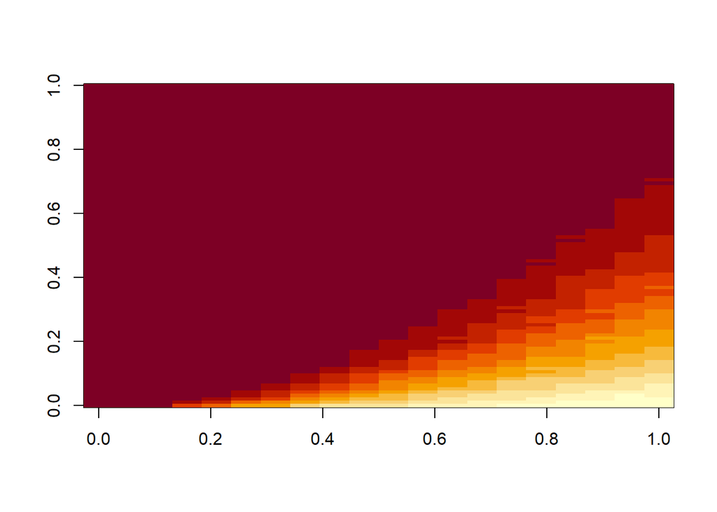

```r
image(sim_output_3)
```

```r
sim_3_dat =
  list(
    power       = sim_output_3,
    sample_size = sample_sizes,
    pop_sd      = pop_sds)


# You should save your simulation results so you don't have to run it every time.
save(
  sim_3_dat,
  file = here::here("data", "lab_ll_sim_output_dispersion_n_1000.RData"))
```

**Q3 (2 pts.): Include a figure of your contour plot in your report.**

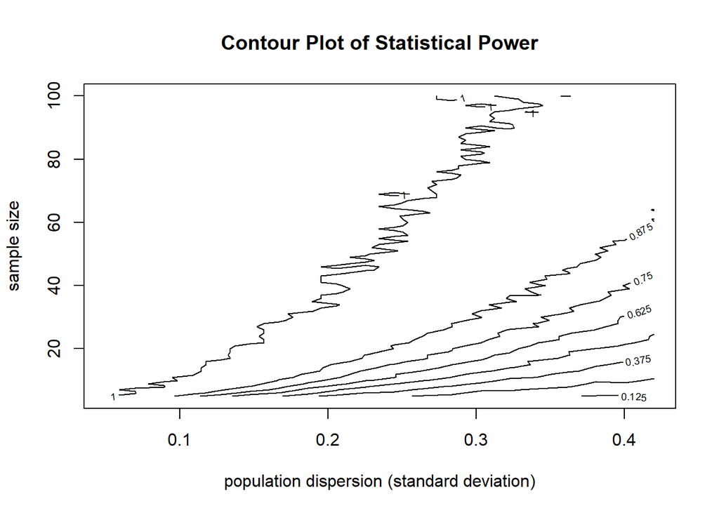

```r
#Create a contour plot of the sample size and population dispersion power simulation.

contour(
  x = sim_3_dat$pop_sd,
  y = sim_3_dat$sample_size,
  z = sim_3_dat$power,
  xlab = "population dispersion (standard deviation)",
  ylab = "sample size",
  main = "Contour Plot of Statistical Power",
  levels = seq(0, 1, length.out = 9),
  drawlabels = TRUE,
  # method = "simple")
  method = "edge")
```

**Q4 (2 pts.): Qualitatively describe the patterns you see in the contour plot. Make sure you discuss the effects of sample size and population dispersion on statistical power.**

When the population dispersion is very low, all that is needed is a small sample size (around 10) in order to obtain a power of 1. However, as the population dispersion increases, we can see from the contours that a much higher sample size is needed to obtain statistical power of 1. This is obvious from the fact that the curve for a statistical power of 1 has a much steeper slope as the population dispersion increases, compared to the curves for lower power values. If we knew the population dispersion was likely to be around 0.4, we might aim for a statistical power around 0.875 using a sample size of 60. If we aimed for a power of 1 in this scenario, we would need to invest much more time and resources in a larger sample size to obtain the desired statistical power.

# **Q5-6: Dispersion and Statistical Power**

```r
persp3d(
   x = sim_3_dat$pop_sd,
  y = sim_3_dat$sample_size,
  z = sim_3_dat$power,
  xlab = "population dispersion (standard deviation)",
  ylab = "sample size", zlab = "power",
  col = 'yellow',
  theta = 30, phi = 30, expand = .75,
  ticktype = 'detailed')
```

```r
#save interactive plot to html file

require(htmlwidgets)
saveWidget(
  rglwidget(),
  file = here(
    "sim_3_dat_power_sim_plot.html"),
  selfcontained = TRUE
)
```

**Q5 (5 pts.): Upload your plot as an interactive html html file. NOTE: some Mac users are not able to use RGL. You may also upload a static plot created with persp() if you can’t get RGL to work on your computer.**

**Q6 (2 pts.): Describe how you could use the information shown in your plot when designing an experiment.**

The plot could help you decide on a reasonable sample size to aim for when designing an experiment. If you know what the population dispersion is likely to be for your sample, you could use the plot to decide how big of a sample size to use in order to obtain adequate power. You might decide to sacrifice a bit of statistical power in order to save money and aim for a smaller sample size. On the other hand, you might decide it is worthwhile to aim for the highest statistical power possible given your expected population dispersion, and this plot could show which sample size would likely achieve that goal.